# Лабораторная работа №14

Именованные каналы

Рогожина Н.А.

Российский университет дружбы народов, Москва, Россия

14 апреля 2023

# Информация

## Докладчик

- Рогожина Надежда Александровна
- Студентка 1го курса, НКАбд-02-22
- Компьютерные и информационные науки
- Российский университет дружбы народов
- [Github](https://github.com/MikoGreen/study_2022-2023_os-intro)

# Вводная часть

## Цели и задачи

- Приобретение практических навыков работы с именованными каналами.

# Содержание лабораторной работы

## Введение

Одним из видов взаимодействия между процессами в операционных системах является обмен сообщениями. Под сообщением понимается последовательность байтов, передаваемая от одного процесса другому. В операционных системах типа UNIX есть 3 вида межпроцессорных взаимодействий:

```
- общеюниксные (именованные каналы, сигналы),
- System V Interface Definition (SVID — разделяемая память, очередь сообщений, семафоры) и
- BSD (сокеты)
```

## Введение

Для передачи данных между неродственными процессами можно использовать механизм именованных каналов (named pipes). Данные передаются по принципу FIFO (First In First Out) (первым записан — первым прочитан), поэтому они называются также FIFO pipes или просто FIFO. Именованные каналы отличаются от неименованных наличием идентификатора канала, который представлен как специальный файл (соответственно имя именованного канала — это имя файла). Поскольку файл находится на локальной файловой системе, данное IPC используется внутри одной системы.

# Задание

## Задачи:

Изучите приведённые в тексте программы server.c и client.c. Взяв данные примеры за образец, напишите аналогичные программы, внеся следующие изменения:

1. Работает не 1 клиент, а несколько (например, два).
2. Клиенты передают текущее время с некоторой периодичностью (например, раз в пять секунд). Используйте функцию sleep() для приостановки работы клиента.
3. Сервер работает не бесконечно, а прекращает работу через некоторое время (например, 30 сек). Используйте функцию clock() для определения времени работы сервера.

# Выполнение

## Создание файла для первого клиента

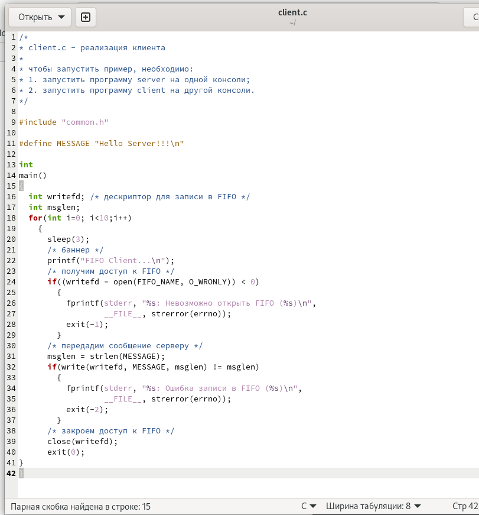

client.c

## Создание файла для второго клиента

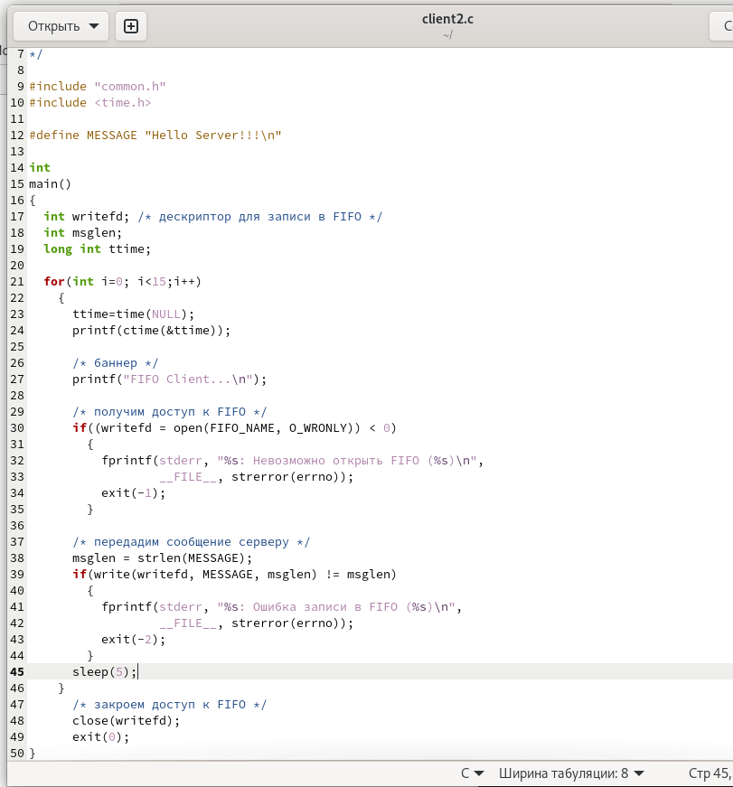

client2.c

## Создание файла сервера

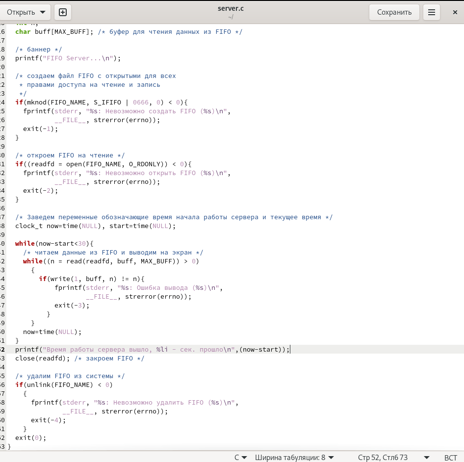

server.c

## Создание заголовочного файла со стандартными определениями

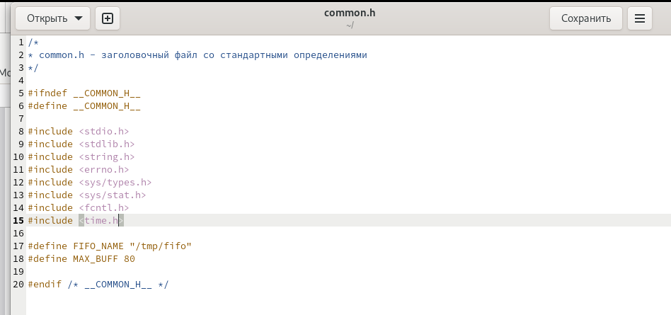

common.h

## Создание makefile

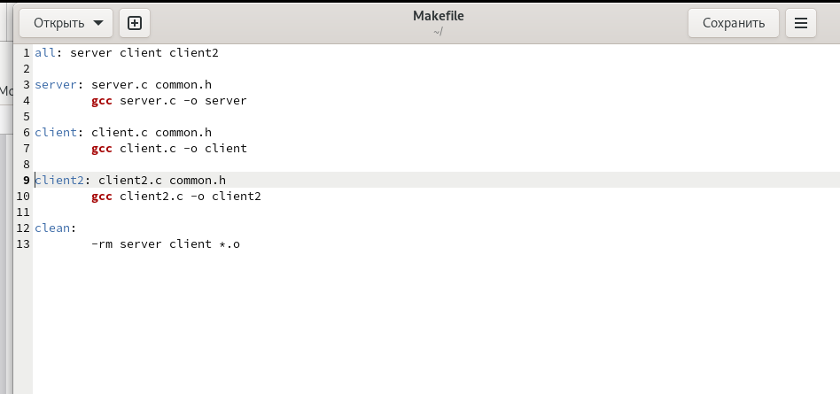

Makefile

## Запуск make

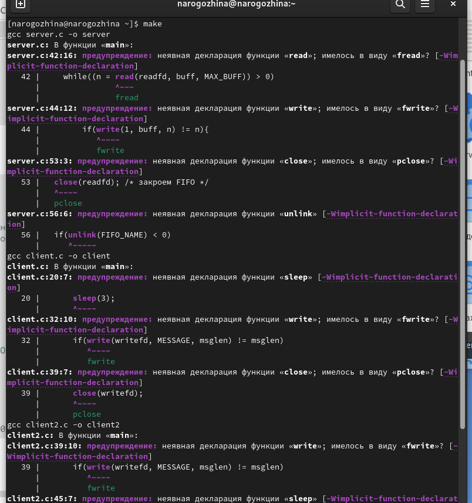

make

## Запуск сервера и клиентов

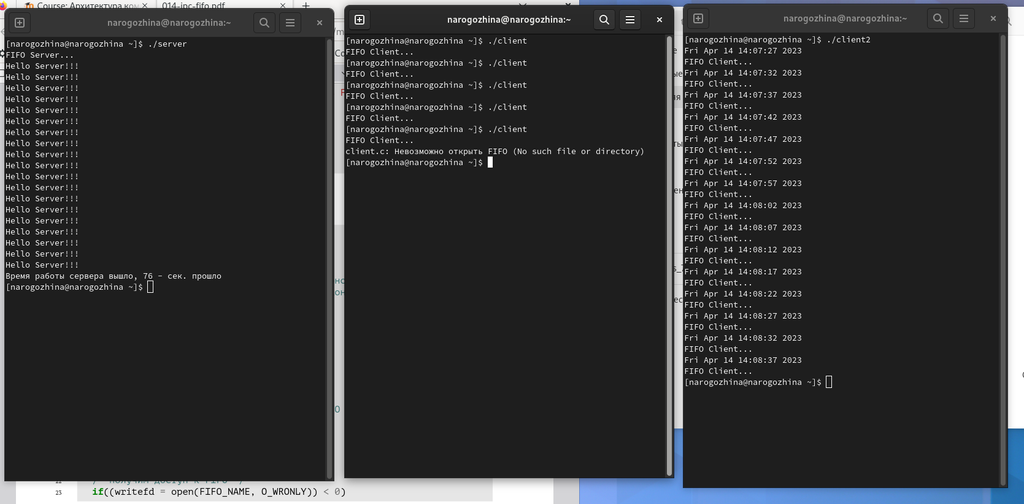

Запуск сервера с клиентами

# Выводы

## Выводы

В ходе лабораторной работы мы приобрели практические навыки работы с именованными каналами.